# Categorical Auto-RQA

Fred Hasselman

1/14/2019

- Watch [**Assignment Lecture: Auto RQA**](https://youtu.be/ElJxBvM1W9g) video before you make these assignments.
- [Chapter 8, 9](https://complexity-methods.github.io/book/unordered-categorical-data.html) summarises most of the information in the video lecture.
- Install R package *casnet*, [follow these instructions](https://fredhasselman.com/casnet/).

# 5 (Cross-) Recurrence Quantification Analysis Software

There are several packages in `R` you could use to do `(C)RQA` analyses, but you can also find a `Matlab` toolbox for `(C)RQA` here: [CRP toolbox](http://tocsy.pik-potsdam.de/CRPtoolbox/), there are `Python` libraries as well, see [this page](http://www.recurrence-plot.tk/programmes.php) for an overview of software. We will use the functions in package `casnet`.

The package `crqa()` was mainly designed to run categorical Cross-Recurrence Quantification Analysis (see [Coco & Dale (2014)](http://journal.frontiersin.org/Journal/10.3389/fpsyg.2014.00510/abstract) and for R code see appendices in [Coco & Dale (2013)](http://arxiv.org/abs/1310.0201)). The article itself is a good reference work for details on how to conduct RQA analysis.

## 5.1 **Categorical Auto-RQA**

### 5.1.1 RQA by ‘hand’

Let’s start with a small time series… open and/or download this Google sheet: https://docs.google.com/spreadsheets/d/1k4FYDbszfCReCM5_wcw6NIEgSFtTPIy3qmf-kFiZjy8/edit?usp=sharing

The spreadsheet displays a short categorical time series of 5 observed categories labelled `A` through `E`. Below the time series a matrix is displayed with zeroes in the upper triangle. The columns and rows of the matrix are labelled according to the categorical time series **y** in `B2:B13`, starting in the lower left corner. The *Line Of Incidence* (LOI) is the diagonal of the matrix going from the lower left corner to the upper right corner. Like the diagonal of a correlation matrix, the LOI in Auto-RQA will contain only recurrent points (`1`), because that’s where the column labels will be identical to the row labels.

#### Questions

Because this is Auto-RQA and we are comparing the time series to itself, the recurrence matrix will be symmetrical, so we only have to look at the upper triangle.

- Fill the upper triangle with recurrent points by changing a `0` into a `1`
  - Start with the label in cell `C29` (**A**) and look upwards (`C27` to `C17`). If you see the value **A** recurring, change the `0` into a `1`
  - Proceed to `D29` and find recurrences of the value **B** in the future (in `D26` to `D17`)
  - Continue to fill the upper triangle
- Count the number of `1`s, the recurrent points (`RN`) and put the value in cell `B32` (*Total*)
- Count how many recurrent points are part of a vertical line, and how many are on a diagonal line, put the values in cell `B33` and `B34` respectively.
- Diagonal line lengths:
  - Determine the frequency of occurrence of specific lengths of diagonal lines, record the values in cells `Q17` to `Q20`
  - Record the maximal diagonal line length in `V22`
  - The mean of the lengths of diagonal lines (*L*) will be calculated in cell `V21`
- Vertical line lengths:
  - Determine the frequency of occurrence of specific lengths of vertical lines, record the values in cells `Q24` to `Q27`
  - Record the maximal vertical line length in `V27`
  - The mean of the lengths of vertical lines (*Trapping Time*) will be calculated in cell `V21`
- Several values are auto-calculated, if you click on the cell you can see how this is done, by looking at the formula bar.
  - Can you understand the calculation of the number of possible recurrent points in `X17`?
- Suppose you randomise the time series… which of the following values do you think would change, and in what way (larger/smaller)
  - Recurrence Rate (`RR`)
  - Mean diagonal line length (`L`, or `MEAN_dl`)
  - Maximum diagonal line length (`L_max`, or `MAX_dl`)
  - Entropy of distribution of diagonal line lengths (`L_entr`, or `ENT_dl`)

## 5.2 **Phase Space Reconstruction and Continuous Auto-RQA**

Here is a great video summary of the phase space reconstruction technique: https://youtu.be/6i57udsPKms

**R-packages for Phase Space Reconstruction**

You can use package `rgl` to visualize an interactive 3D state space. Package `rgl` is used for plotting and can cause problems on some Windows machines. On Windows You’ll need to check if you have the [X Window System](http://www.x.org/wiki/) for interactive 3D plotting. This Linux desktop system comes installed in some way or form on most Mac and Windows systems. You can test if it is present by running `rgl::open3d()` in `R`, which will try to open an interactive plotting device.

If this fails you can try package `plot3D` which is not interactive, for example `lines3D()`, or, `scatter3D()`.

### 5.2.1 Reconstruct the Lorenz attractor

The dataset `lorenz` includes the 3 dimensions of the Lorenz system in the chaotic regime. Running the code below will produce an interactive 3D plot of the strange attractor.

```r
library(rio)
library(rgl)
library(plot3D)

lorenz <- rio::import("https://complexity-methods.github.io/assignments/Data/lorenz.csv")

rgl::plot3d(lorenz,type="l")
```

We’ll reconstruct the attractor based on just dimension `X` of the system using the data in `lorenz` and functions from package `casnet`.

> Don’t forget: **always look at the manual pages of a function** you are running.

#### Questions

- Use `lx <- lorenz[1:1024,1]` to reconstruct the phase space based on `lx`.
  - Find an optimal embedding lag and dimension by calling `est_parameters()`.
  - Use `nnThres = .01`. This is the proportion of remaining nearest neighbours below which we consider the number of dimensions optimal. Because this time series was generated by a simulation of a system, we can use a much lower threshold. For real data, which is much noisier, you can use `0.1` or `0.2`.
  - **NOTE:** If you have a slow computer don’t use `1024`, but use e.g. `512`.

This `est_parameters()` function will call several other functions (e.g. `nonlinearTseries::findAllNeighbours()` for the false nearest neighbourhood search). Look at the manual page, you can run the `est_parameters()` function with the defaults settings, it will show a diagnostic plot. Because we have to search over a range of parameters it can take a while to get the results…

- Based on the output:
  - Choose an embedding lag $\tau$ (in `casnet` functions this is the argument `emLag`). Remember, this is just an optimisation choice. Sometimes there is no first minimum, or no global minimum.
  - Find an appropriate embedding dimension by looking when the false nearest neighbours drop below 1%.
- Now you can use this information to reconstruct the phase space:
  - Embed the time series using `ts_embed()`).
  - Inspect the object that was returned
  - Use `rgl::plot3d()` to plot the reconstructed space. Plot the reconstructed phase space.

#### Answers

- Use `lx <- lorenz[1:1024,1]` to reconstruct the phase space based on `lx`.
  - Find an optimal embedding lag and dimension by calling `est_parameters()`.

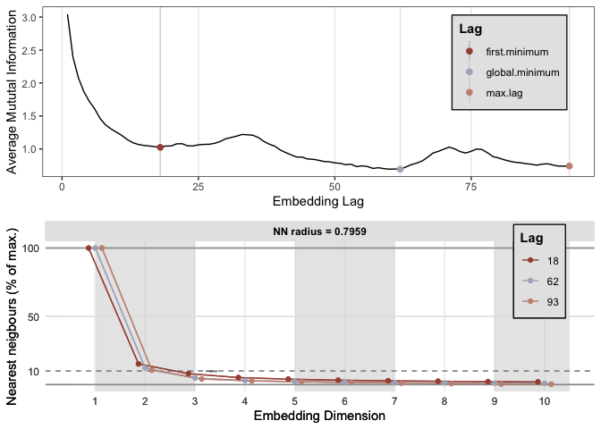

```r
library(rgl)
library(plot3D)
library(ggplot2)
library(invctr)
library(casnet)

# The X data
lx <- lorenz[1:1024,1]

# Search for the parameters,
params <- est_parameters(lx)
```

```r
# Assign the optimal parameters
emLag <- params$optimLag
emDim <- params$optimDim
```

- Now you can use this information to reconstruct the phase space

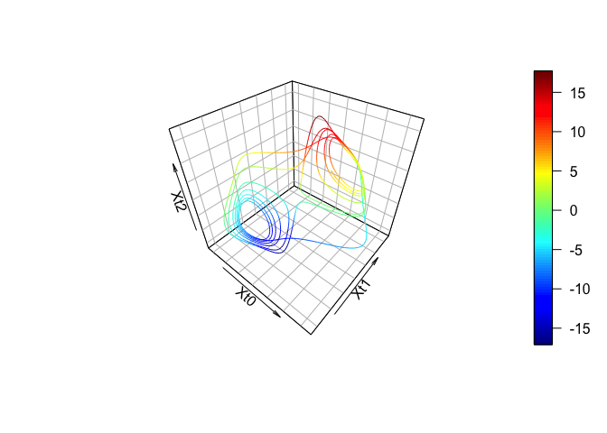

```r
# For X
lx_emb <- data.frame(ts_embed(y=lx,emLag = emLag, emDim = emDim))

rgl::plot3d(lx_emb, type="l")

# Or use plot3D
plot3D::lines3D(lx_emb$tau.0, lx_emb$tau.1, lx_emb$tau.2,  xlab= "Xt0", ylab = "Xt1", zlab ="Xt2", bty = "b2", lwd=1, theta = 40, phi = 40)
```

```r
# For Y
ly <- lorenz[1:1024,2]

# Search for the parameters,
params <- est_parameters(ly)
```

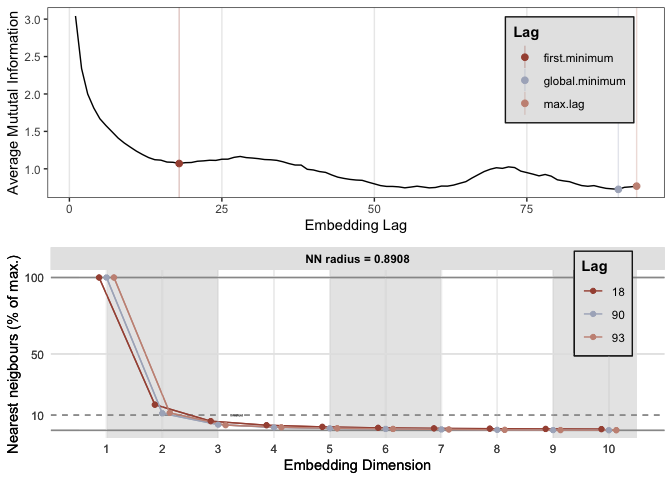

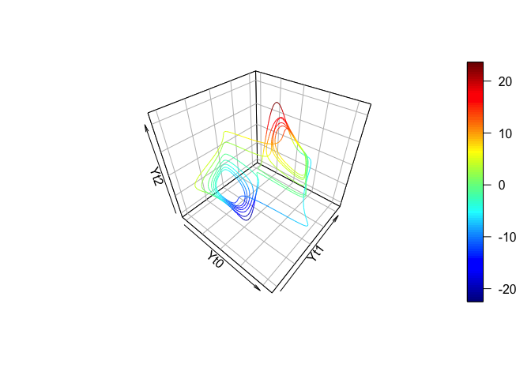

```r
# Assign the optimal parameters
emLag <- params$optimLag
emDim <- params$optimDim

# Embed the time series
ly_emb <- data.frame(ts_embed(y=ly,emLag = emLag, emDim = emDim))
rgl::plot3d(ly_emb,type="l")

# Or use plot3D
plot3D::lines3D(ly_emb$tau.0, ly_emb$tau.1, ly_emb$tau.2,  xlab= "Yt0", ylab = "Yt1", zlab ="Yt2", bty = "b2", lwd=1, theta = 40, phi = 40)
```

```r
# For Z
lz <- lorenz[1:1024,3]

# Search for the parameters,
params <- est_parameters(lz)
```

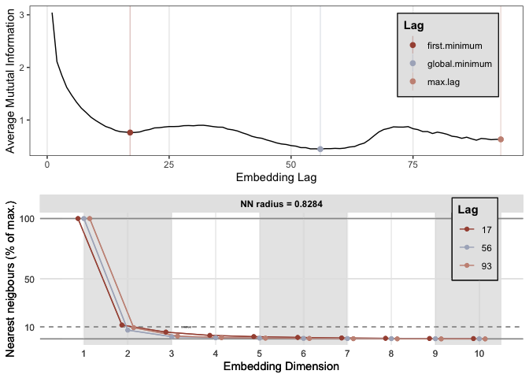

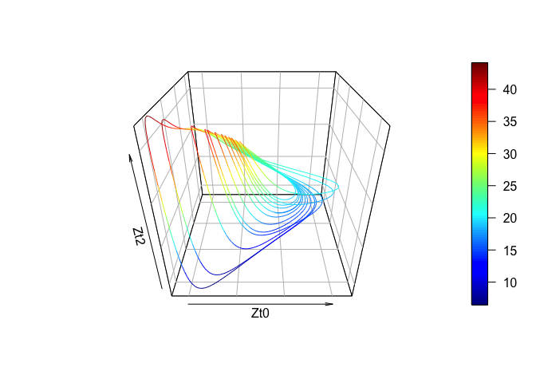

```r
# Assign the optimal parameters
emLag <- params$optimLag
emDim <- params$optimDim

# Embed the time series
lz_emb <- data.frame(ts_embed(y=lz,emLag = emLag, emDim = emDim))
rgl::plot3d(lz_emb,type="l")

# Or use plot3D
plot3D::lines3D(lz_emb$tau.0, lz_emb$tau.1, lz_emb$tau.2,  xlab= "Zt0", ylab = "Zt1", zlab ="Zt2", bty = "b2", lwd=1, theta = 0, phi = 30)
```

## 5.3 Continuous Auto-RQA

### 5.3.1 RQA of the Lorenz attractor

Perform an RQA on the reconstructed state space of the Lorenz system. You’ll need a radius (also called: threshold, or $\epsilon$) in order to decide which points are close together (recurrent). You have already seen `casnet` provides a function which will automatically select the best parameter settings for phase space reconstruction: `est_parameters()`.

#### Questions

- First get a radius that gives you a fixed recurrence rate use `est_radius()` look at the manual pages. The function `rp()` will also call `est_radius` if you provide `emRad = NA`.
- Best way to ensure you are using the same parameters in each function is to create some lists with parameter settings (check the `rp_cl()` or `rp()` manual to figure out what these parameters mean)

#### Answers

```r
library(casnet)

# Lorenz X
lx <- lorenz[1:1024,1]
emLag = 17
emDim = 3

(emRad <- est_radius(y1 = lx, emLag = emLag, emDim = emDim)$Radius)
```

```
## <sparse>[ <logic> ] : .M.sub.i.logical() maybe inefficient
```

```
##
## Searching for a radius that will yield 0.05 ± 0.01 for RR
## Iteration 1
```

```
##
## Converged! Found an appropriate radius...
```

```
## [1] 3.718859
```

```r
# RQA analysis
#(out <- rp_cl(lx,emDim = emDim, emLag = emLag, emRad = emRad))
RMx <- rp(y1 = lx, emDim = emDim, emLag = emLag, emRad = emRad)
out <- rp_measures(RMx, silent = FALSE)
```

```
##
## ~~~o~~o~~casnet~~o~~o~~~
##  Global Measures
##   Global Max.points N.points   RR Singular Divergence Repetitiveness
## 1 Matrix     979110    48956 0.05       56    0.00101              2
##
##
##  Line-based Measures
##        Lines N.lines N.points Measure  Rate  Mean Max.  ENT ENT_rel   CoV
## 1   Diagonal    1982    48900     DET 0.999 24.67  989 3.64   0.528 2.417
## 2   Vertical    5598    48897   V LAM 0.999  8.73   26 2.76   0.400 0.475
## 3 Horizontal    5598    48897   H LAM 0.999  8.73   26 2.76   0.400 0.475
## 4  V+H Total   11196    97794 V+H LAM 0.999  8.73   26 2.76   0.400 0.475
##
## ~~~o~~o~~casnet~~o~~o~~~
```

We can plot the recurrence matrix…

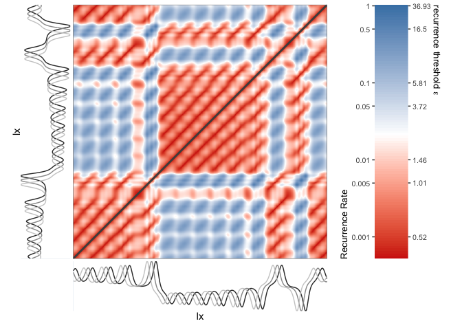

```r
library(casnet)

# Unthresholded matrix (no radius applied)
RM <- rp(y1 = lx, emDim = emDim, emLag = emLag)

# plot it
rp_plot(RM, plotDimensions = TRUE)
```

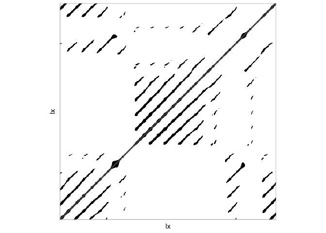

```r
# Thresholded by the radius
RMth <- mat_di2bi(RM,emRad = emRad)

# You can also call rp with emRad = NA and doPlot = TRUE
RMth <- rp(y1 = lx, emDim = emDim, emLag = emLag, emRad = NA, doPlot = TRUE)
```

### 5.3.2 Distinguish between Logistic Map and White noise?

RQA promises to be able to distinguish between different dynamical regimes, for example dynamics due to different parameter settings of the logistic map, see e.g. https://en.wikipedia.org/wiki/Recurrence_quantification_analysis#Time-dependent_RQA

#### Questions

- Use RQA to compare white noise (TS_1) to the deterministic chaos series of previous assignments (TS_3).
  - You can shorten the time series by half to run RQA on a slow computer.
- Estimate the parameters
  - Did you expect to get these values?
  - Choose the same lag and dimension for both series, use the median of the lags and the maximum of the dimension.
- Produce an unthresholded matrix
- Choose a recurrence threshold to get `RR = 0.05` (either by looking at the color bar or by estimating with a function) and plot the recurrence plot.
- Compare the RQA measures.
  - Think about the properties of deterministic chaos when you interpret the results.
  - RQA is very powerful when detecting different dynamical regimes: https://en.wikipedia.org/wiki/Recurrence_quantification_analysis#Example

```r
# Reload the data
library(rio)
series <- rio::import("https://github.com/complexity-methods/CSA-assignments/raw/master/assignment_data/BasicTSA_arma/series.xlsx")
```

#### Answers

- Shorten the series

```r
TS1 <- series$TS_1[1:512]
TS3 <- series$TS_3[1:512]
```

- Parameters
  - Remember that you need at least 3 coupled differential equations to get deterministic chaos.

```r
library(casnet)
out1 <- est_parameters(TS1)
```

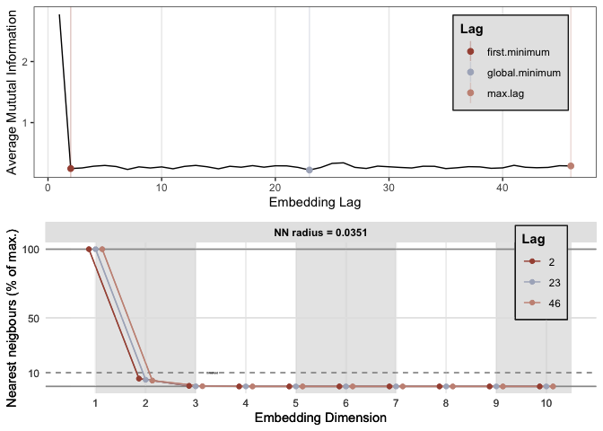

```r
out3 <- est_parameters(TS3)
```

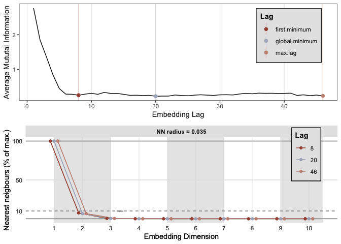

```r
emLag <- median(out1$optimLag,out3$optimLag)
emDim <- max(out1$optimDim,out3$optimDim)
```

- Plots

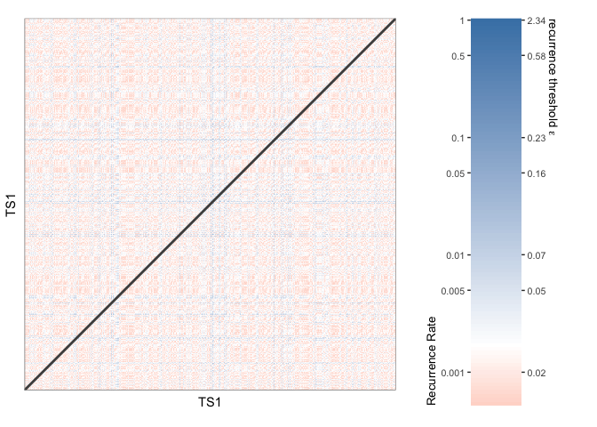

```r
# Unthresholded
RM1 <- rp(y1 = TS1, emDim = emDim, emLag = emLag)
rp_plot(RM1)
```

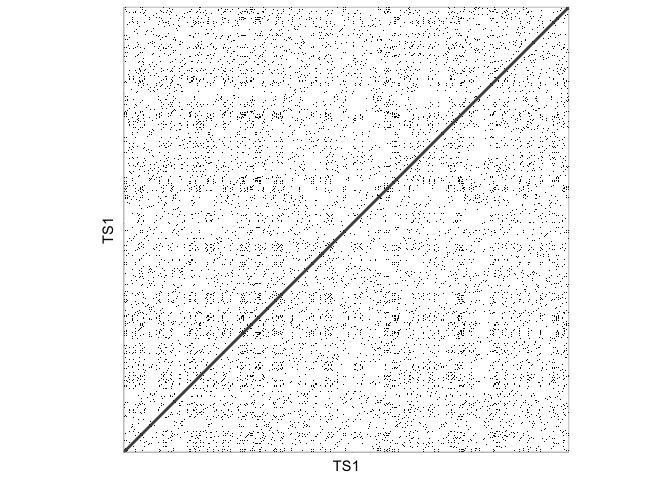

```r
# Thresholded
RM1t <- rp(y1 = TS1, emDim = emDim, emLag = emLag, emRad = NA)
rp_plot(RM1t)
```

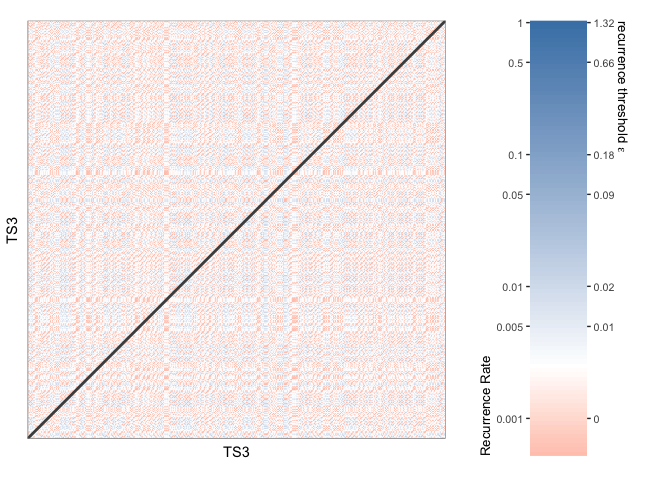

```r
# Unthresholded
RM3 <- rp(y1 = TS3, emDim = emDim, emLag = emLag)
rp_plot(RM3)
```

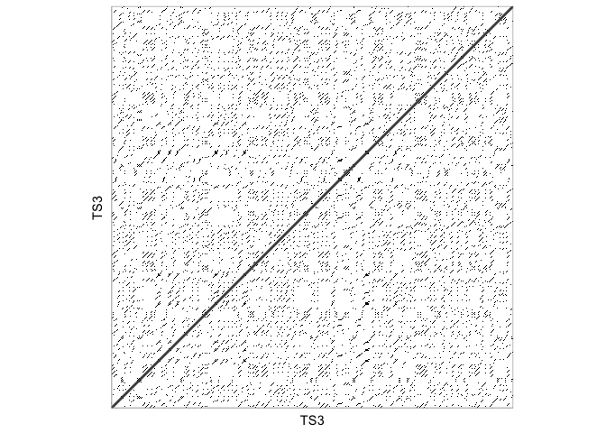

```r
# Thresholded
RM3t <- rp(y1 = TS3, emDim = emDim, emLag = emLag, emRad = NA)
rp_plot(RM3t)
```

- Measures

```r
library(casnet)
rqa1 <- rp_measures(RM1t, silent = FALSE)
```

```
##
## ~~~o~~o~~casnet~~o~~o~~~
##  Global Measures
##   Global Max.points N.points   RR Singular Divergence Repetitiveness
## 1 Matrix     259590    12980 0.05    11776      0.143           3.11
##
##
##  Line-based Measures
##        Lines N.lines N.points Measure   Rate Mean Max.   ENT ENT_rel   CoV
## 1   Diagonal     516     1204     DET 0.0928 2.33    7 0.745   0.120 0.297
## 2   Vertical     900     1870   V LAM 0.1441 2.08    5 0.268   0.043 0.163
## 3 Horizontal     900     1870   H LAM 0.1441 2.08    5 0.268   0.043 0.163
## 4  V+H Total    1800     3740 V+H LAM 0.1441 2.08    5 0.268   0.043 0.163
##
## ~~~o~~o~~casnet~~o~~o~~~
```

```r
rqa3 <- rp_measures(RM3t, silent = FALSE)
```

```
##
## ~~~o~~o~~casnet~~o~~o~~~
##  Global Measures
##   Global Max.points N.points   RR Singular Divergence Repetitiveness
## 1 Matrix     259590    12980 0.05     3964     0.0556         0.0796
##
##
##  Line-based Measures
##        Lines N.lines N.points Measure   Rate Mean Max.   ENT ENT_rel   CoV
## 1   Diagonal    2890     9016     DET 0.6946 3.12   18 1.459   0.234 0.497
## 2   Vertical     141      359   V LAM 0.0277 2.55    5 0.942   0.151 0.310
## 3 Horizontal     141      359   H LAM 0.0277 2.55    5 0.942   0.151 0.310
## 4  V+H Total     282      718 V+H LAM 0.0277 2.55    5 0.942   0.151 0.309
##
## ~~~o~~o~~casnet~~o~~o~~~
```